# Explaining Box Plots

## Showing IQR with Distribution

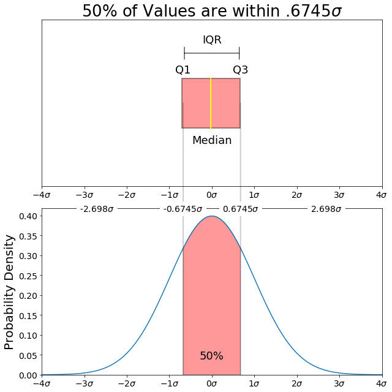

```python
np.random.seed(916170)


# 916170 is new seed
# 39 was the seed

# connection path is here: https://stackoverflow.com/questions/6146290/plotting-a-line-over-several-graphs
mu, sigma = 0, 1 # mean and standard deviation
s = np.random.normal(mu, sigma, 1000)

fig, axes = plt.subplots(nrows = 2, ncols = 1, figsize=(9, 9))

# rectangular box plot
bplot = axes[0].boxplot(s,
                vert=False,
                patch_artist=True,
                showfliers=False, # This would show outliers (the remaining .7% of the data)
                positions = [0],
                boxprops = dict(linestyle='--', linewidth=2, color='Black', facecolor = 'Red', alpha = .4),
                medianprops = dict(linestyle='-', linewidth=2, color='Yellow'),
                whiskerprops = dict(linestyle='-', linewidth=2, color='White', alpha = .4),
                capprops = dict(linestyle='-', linewidth=2, color='White'),
                flierprops = dict(marker='o', markerfacecolor='green', markersize=10,
                  linestyle='none', alpha = .4),
                widths = .3,
                zorder = 1)

axes[0].set_title('50% of Values are within .6745$\sigma$', fontdict = {'fontsize': 26, 'fontweight': 'medium'});



#axes.set_title('Stuff', fontdict = {'fontsize': 29,
#                                    'fontweight': 'bold'} )

axes[0].set_xlim(-4, 4)
axes[0].set_yticks([])
x = np.linspace(-4, 4, num = 100)
constant = 1.0 / np.sqrt(2*np.pi)
pdf_normal_distribution = constant * np.exp((-x**2) / 2.0)

axes[0].annotate(r'',
            xy=(-.6745, .30), xycoords='data',
            xytext=(.6745, .30), textcoords='data',
            arrowprops=dict(arrowstyle="|-|",
                            connectionstyle="arc3")
            );

axes[0].text(0, .36, r"IQR",  horizontalalignment='center', fontsize=18)
axes[0].text(0, -.24, r"Median", horizontalalignment='center', fontsize=18);
axes[0].text(-.6745, .18, r"Q1", horizontalalignment='center', fontsize=18);
#axes[0].text(-2.698, .12, r"Q1 - 1.5*IQR", horizontalalignment='center', fontsize=16);
axes[0].text(.6745, .18, r"Q3", horizontalalignment='center', fontsize=18);
#axes[0].text(2.698, .12, r"Q3 + 1.5*IQR", horizontalalignment='center', fontsize=16);

axes[1].plot(x, pdf_normal_distribution, zorder= 2)
axes[1].set_xlim(-4, 4)
axes[1].set_ylim(0)
axes[1].set_ylabel('Probability Density', size = 20)

##############################
# lower box
con = ConnectionPatch(xyA=(-.6745, 0), xyB=(-.6745, 0),
    coordsA="data", coordsB="data", axesA=axes[1], axesB=axes[0],
    arrowstyle="-", linewidth=2, color="black", zorder = 2, alpha = .2)
axes[1].add_artist(con)

# upper box
con = ConnectionPatch(xyA=(.6745, 0), xyB=(.6745, 0),
    coordsA="data", coordsB="data", axesA=axes[1], axesB=axes[0],
    arrowstyle="-", linewidth=2, color="black", zorder = 2, alpha = .2)
axes[1].add_artist(con)

# Make the shaded center region to represent integral
a, b = -.6745, .6745
ix = np.linspace(a, b)
iy = normalProbabilityDensity(ix)
verts = [(-.6745, 0)] + list(zip(ix, iy)) + [(.6745, 0)]
poly = Polygon(verts, facecolor='red', edgecolor='0.2', alpha = .4)
axes[1].add_patch(poly)

##############################
xTickLabels = [r'$-4\sigma$',
               r'$-3\sigma$',
               r'$-2\sigma$',
               r'$-1\sigma$',
               r'$0\sigma$',
               r'$1\sigma$',
               r'$2\sigma$',
               r'$3\sigma$',
               r'$4\sigma$']

yTickLabels = ['0.00',
               '0.05',
               '0.10',
               '0.15',
               '0.20',
               '0.25',
               '0.30',
               '0.35',
               '0.40']

# Make both x axis into standard deviations
axes[0].set_xticklabels(xTickLabels, fontsize = 14)
axes[1].set_xticklabels(xTickLabels, fontsize = 14)

# Only the PDF needs y ticks
axes[1].set_yticklabels(yTickLabels, fontsize = 14)

##############################
# Add -2.698, -.6745, .6745, 2.698 text without background
axes[1].text(-.6745,.41, r'{0:.4f}'.format(-.6745) + '$\sigma$', horizontalalignment='center', fontsize=14,
            bbox={'facecolor':'white', 'edgecolor':'none', 'pad':5});

axes[1].text(.6745, .410, r'{0:.4f}'.format(.6745) + '$\sigma$', horizontalalignment='center', fontsize=14,
            bbox={'facecolor':'white', 'edgecolor':'none', 'pad':5});

axes[1].text(-2.698, .410, r'{0:.3f}'.format(-2.698) + '$\sigma$', horizontalalignment='center', fontsize=14,
            bbox={'facecolor':'white', 'edgecolor':'none', 'pad':5});

axes[1].text(2.698, .410, r'{0:.3f}'.format(2.698) + '$\sigma$', horizontalalignment='center', fontsize=14,
            bbox={'facecolor':'white', 'edgecolor':'none', 'pad':5});


axes[1].text(0, .04, r'{0:.0f}%'.format(result_50p*100),
         horizontalalignment='center', fontsize=18)

fig.tight_layout()
fig.savefig('images/IQRboxplotDistribution.png', dpi = 900)
```

# Math Expression

$$\Huge \int_{-2.698}^{2.698}\frac{1}{\sqrt{2\pi}}e^{-x^{2}/2}\mathrm{d}x$$

```python
# Make a PDF for the normal distribution a function
def normalProbabilityDensity(x):
    constant = 1.0 / np.sqrt(2*np.pi)
    return(constant * np.exp((-x**2) / 2.0) )

# Integrate PDF from -2.698 to 2.698
result_99_3p, _ = quad(normalProbabilityDensity,
                     -2.698,
                     2.698,
                     limit = 1000)
print(result_99_3p)
```

```
0.993024255934
```

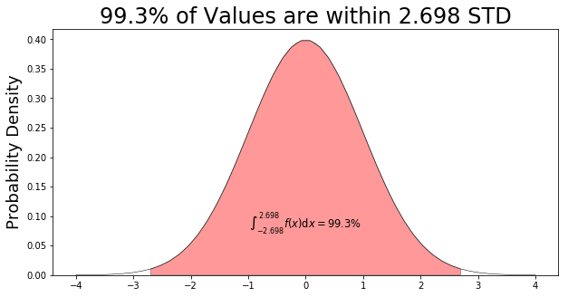

```python
a, b = -2.698, 2.698 # integral limits

x = np.linspace(-4, 4)
y = normalProbabilityDensity(x)

fig, ax = plt.subplots(figsize=(10, 5))
ax.plot(x, y, 'k', linewidth=.5)
ax.set_ylim(ymin=0)

# Make the shaded region
ix = np.linspace(a, b)
iy = normalProbabilityDensity(ix)
verts = [(a, 0)] + list(zip(ix, iy)) + [(b, 0)]
poly = Polygon(verts, facecolor='red', edgecolor='0.2', alpha = .4)
ax.add_patch(poly);

ax.text(0, .08, r"$\int_{-2.698}^{2.698}f(x)\mathrm{d}x=$" + "{0:.1f}%".format(result_99_3p*100),
         horizontalalignment='center', fontsize=11.5);

ax.set_title(r'99.3% of Values are within 2.698 STD', fontsize = 24);
ax.set_ylabel(r'Probability Density', fontsize = 18);

fig.savefig('images/99_3.png', dpi = 1200)
```

99.3% of the data is within 2.698 standard deviations (σ) of the mean (μ).

## Showing Whiskers with Distribution

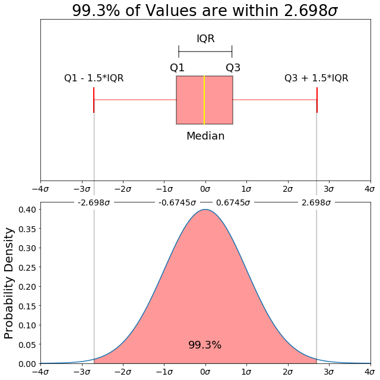

```python
np.random.seed(916170)

# 8, 11, 20

# connection path is here: https://stackoverflow.com/questions/6146290/plotting-a-line-over-several-graphs
mu, sigma = 0, 1 # mean and standard deviation
s = np.random.normal(mu, sigma, 1000)

fig, axes = plt.subplots(nrows = 2, ncols = 1, figsize=(9, 9))

# rectangular box plot
bplot = axes[0].boxplot(s,
                vert=False,
                patch_artist=True,
                showfliers=False, # This would show outliers (the remaining .7% of the data)
                positions = [0],
                boxprops = dict(linestyle='--', linewidth=2, color='Black', facecolor = 'red', alpha = .4),
                medianprops = dict(linestyle='-', linewidth=2, color='Yellow'),
                whiskerprops = dict(linestyle='-', linewidth=2, color='red', alpha = .4),
                capprops = dict(linestyle='-', linewidth=2, color='red'),
                widths = .3,
                zorder = 1)

axes[0].set_title('99.3% of Values are within 2.698$\sigma$', fontdict = {'fontsize': 26, 'fontweight': 'medium'});

axes[0].set_xlim(-4, 4)
axes[0].set_yticks([])
x = np.linspace(-4, 4, num = 100)
constant = 1.0 / np.sqrt(2*np.pi)
pdf_normal_distribution = constant * np.exp((-x**2) / 2.0)

axes[0].annotate(r'',
            xy=(-.6745, .30), xycoords='data',
            xytext=(.6745, .30), textcoords='data',
            arrowprops=dict(arrowstyle="|-|",
                            connectionstyle="arc3")
            );

axes[0].text(0, .36, r"IQR",  horizontalalignment='center', fontsize=18)
axes[0].text(0, -.24, r"Median", horizontalalignment='center', fontsize=18);
axes[0].text(-.6745, .18, r"Q1", horizontalalignment='center', fontsize=18);
axes[0].text(-2.698, .12, r"Q1 - 1.5*IQR", horizontalalignment='center', fontsize=16);
axes[0].text(.6745, .18, r"Q3", horizontalalignment='center', fontsize=18);
axes[0].text(2.698, .12, r"Q3 + 1.5*IQR", horizontalalignment='center', fontsize=16);

axes[1].plot(x, pdf_normal_distribution, zorder= 2)
axes[1].set_xlim(-4, 4)
axes[1].set_ylim(0)
axes[1].set_ylabel('Probability Density', size = 20)

##############################
# lower whisker
con = ConnectionPatch(xyA=(-2.698, 0), xyB=(-2.698, 0),
    coordsA="data", coordsB="data", axesA=axes[1], axesB=axes[0],
    arrowstyle="-", linewidth=2, color="black", zorder = 2, alpha = .2)
axes[1].add_artist(con)

# upper whisker
con = ConnectionPatch(xyA=(2.698, 0), xyB=(2.698, 0),
    coordsA="data", coordsB="data", axesA=axes[1], axesB=axes[0],
    arrowstyle="-", linewidth=2, color="black", zorder = 2, alpha = .2)
axes[1].add_artist(con)

# Make the shaded center region to represent integral
a, b = -2.698, 2.6988
ix = np.linspace(a, b)
iy = normalProbabilityDensity(ix)
verts = [(-2.698, 0)] + list(zip(ix, iy)) + [(2.698, 0)]
poly = Polygon(verts, facecolor='red', edgecolor='0.2', alpha = .4)
axes[1].add_patch(poly)
axes[1].text(0, .04, r'{0:.1f}%'.format(result_99_3p*100),
         horizontalalignment='center', fontsize=18)

##############################
xTickLabels = [r'$-4\sigma$',
               r'$-3\sigma$',
               r'$-2\sigma$',
               r'$-1\sigma$',
               r'$0\sigma$',
               r'$1\sigma$',
               r'$2\sigma$',
               r'$3\sigma$',
               r'$4\sigma$']

yTickLabels = ['0.00',
               '0.05',
               '0.10',
               '0.15',
               '0.20',
               '0.25',
               '0.30',
               '0.35',
               '0.40']

# Make both x axis into standard deviations
axes[0].set_xticklabels(xTickLabels, fontsize = 14)
axes[1].set_xticklabels(xTickLabels, fontsize = 14)

# Only the PDF needs y ticks
axes[1].set_yticklabels(yTickLabels, fontsize = 14)

##############################
# Add -2.698, -.6745, .6745, 2.698 text without background
axes[1].text(-.6745,.41, r'{0:.4f}'.format(-.6745) + '$\sigma$', horizontalalignment='center', fontsize=14,
            bbox={'facecolor':'white', 'edgecolor':'none', 'pad':5});

axes[1].text(.6745, .410, r'{0:.4f}'.format(.6745) + '$\sigma$', horizontalalignment='center', fontsize=14,
            bbox={'facecolor':'white', 'edgecolor':'none', 'pad':5});

axes[1].text(-2.698, .410, r'{0:.3f}'.format(-2.698) + '$\sigma$', horizontalalignment='center', fontsize=14,
            bbox={'facecolor':'white', 'edgecolor':'none', 'pad':5});

axes[1].text(2.698, .410, r'{0:.3f}'.format(2.698) + '$\sigma$', horizontalalignment='center', fontsize=14,
            bbox={'facecolor':'white', 'edgecolor':'none', 'pad':5});

fig.tight_layout()
fig.savefig('images/99_3_Distribution.png', dpi = 900)
```

# Math Expression

$$\Huge\int_{-\infty}^{\infty}\frac{1}{\sqrt{2\pi}}e^{-x^{2}/2}\mathrm{d}x$$

```python
# Make PDF for the normal distribution a function
def normalProbabilityDensity(x):
    constant = 1.0 / np.sqrt(2*np.pi)
    return(constant * np.exp((-x**2) / 2.0) )

# Integrate from -inf to +inf
result, _ = quad(normalProbabilityDensity,
                     -np.inf,
                     np.inf,
                     limit = 1000)

print(result)
```

```
1.0
```

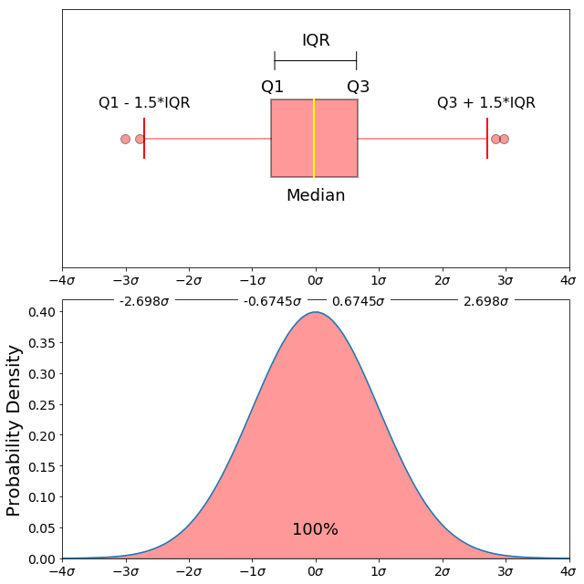

```python
np.random.seed(916170)

# connection path is here: https://stackoverflow.com/questions/6146290/plotting-a-line-over-several-graphs
mu, sigma = 0, 1 # mean and standard deviation
s = np.random.normal(mu, sigma, 1000)

fig, axes = plt.subplots(nrows = 2, ncols = 1, figsize=(9, 9))

# rectangular box plot
bplot = axes[0].boxplot(s,
                vert=False,
                patch_artist=True,
                showfliers=True, # This would show outliers (the remaining .7% of the data)
                positions = [0],
                boxprops = dict(linestyle='--', linewidth=2, color='Black', facecolor = 'red', alpha = .4),
                medianprops = dict(linestyle='-', linewidth=2, color='Yellow'),
                whiskerprops = dict(linestyle='-', linewidth=2, color='red', alpha = .4),
                capprops = dict(linestyle='-', linewidth=2, color='red'),
                flierprops = dict(marker='o', markerfacecolor='red', markersize=10,
                  linestyle='none', alpha = .4),
                widths = .3,
                zorder = 1)

axes[0].set_xlim(-4, 4)
axes[0].set_yticks([])
x = np.linspace(-4, 4, num = 100)
constant = 1.0 / np.sqrt(2*np.pi)
pdf_normal_distribution = constant * np.exp((-x**2) / 2.0)

axes[0].annotate(r'',
            xy=(-.6745, .30), xycoords='data',
            xytext=(.6745, .30), textcoords='data',
            arrowprops=dict(arrowstyle="|-|",
                            connectionstyle="arc3")
            );

axes[0].text(0, .36, r"IQR",  horizontalalignment='center', fontsize=18)
axes[0].text(0, -.24, r"Median", horizontalalignment='center', fontsize=18);
axes[0].text(-.6745, .18, r"Q1", horizontalalignment='center', fontsize=18);
axes[0].text(-2.698, .12, r"Q1 - 1.5*IQR", horizontalalignment='center', fontsize=16);
axes[0].text(.6745, .18, r"Q3", horizontalalignment='center', fontsize=18);
axes[0].text(2.698, .12, r"Q3 + 1.5*IQR", horizontalalignment='center', fontsize=16);

axes[1].plot(x, pdf_normal_distribution, zorder= 2)
axes[1].set_xlim(-4, 4)
axes[1].set_ylim(0)
axes[1].set_ylabel('Probability Density', size = 20)

##############################

# Make the shaded center region to represent integral
a, b = -4, 4
ix = np.linspace(a, b)
iy = normalProbabilityDensity(ix)
verts = [(-.6745, 0)] + list(zip(ix, iy)) + [(.6745, 0)]
poly = Polygon(verts, facecolor='red', edgecolor='0.2', alpha = .4)
axes[1].add_patch(poly)
axes[1].text(0, .04, r'{0:.0f}%'.format(result*100),
         horizontalalignment='center', fontsize=18)

##############################
xTickLabels = [r'$-4\sigma$',
               r'$-3\sigma$',
               r'$-2\sigma$',
               r'$-1\sigma$',
               r'$0\sigma$',
               r'$1\sigma$',
               r'$2\sigma$',
               r'$3\sigma$',
               r'$4\sigma$']

yTickLabels = ['0.00',
               '0.05',
               '0.10',
               '0.15',
               '0.20',
               '0.25',
               '0.30',
               '0.35',
               '0.40']

# Make both x axis into standard deviations
axes[0].set_xticklabels(xTickLabels, fontsize = 14)
axes[1].set_xticklabels(xTickLabels, fontsize = 14)

# Only the PDF needs y ticks
axes[1].set_yticklabels(yTickLabels, fontsize = 14)

##############################
# Add -2.698, -.6745, .6745, 2.698 text without background
axes[1].text(-.6745,.41, r'{0:.4f}'.format(-.6745) + '$\sigma$', horizontalalignment='center', fontsize=14,
            bbox={'facecolor':'white', 'edgecolor':'none', 'pad':5});

axes[1].text(.6745, .410, r'{0:.4f}'.format(.6745) + '$\sigma$', horizontalalignment='center', fontsize=14,
            bbox={'facecolor':'white', 'edgecolor':'none', 'pad':5});

axes[1].text(-2.698, .410, r'{0:.3f}'.format(-2.698) + '$\sigma$', horizontalalignment='center', fontsize=14,
            bbox={'facecolor':'white', 'edgecolor':'none', 'pad':5});

axes[1].text(2.698, .410, r'{0:.3f}'.format(2.698) + '$\sigma$', horizontalalignment='center', fontsize=14,
            bbox={'facecolor':'white', 'edgecolor':'none', 'pad':5});

fig.tight_layout()
fig.savefig('images/combined100.png', dpi = 900)
```

## New Stuff

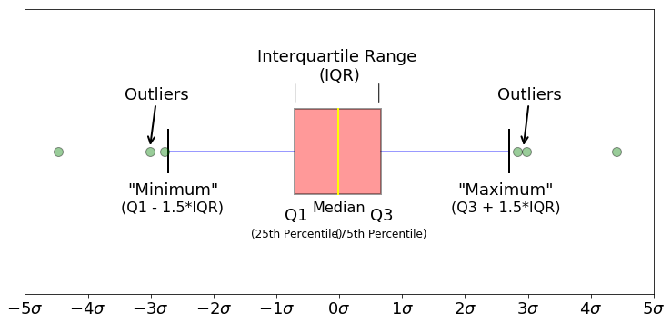

```python
np.random.seed(916170)

# connection path is here: https://stackoverflow.com/questions/6146290/plotting-a-line-over-several-graphs
mu, sigma = 0, 1 # mean and standard deviation
s = np.random.normal(mu, sigma, 1000)

fig, axes = plt.subplots(nrows = 1, ncols = 1, figsize=(10, 5))

# rectangular box plot
bplot = axes.boxplot(s,
                vert=False,
                patch_artist=True,
                showfliers=True, # This would show outliers (the remaining .7% of the data)
                positions = [0],
                boxprops = dict(linestyle='--', linewidth=2, color='Black', facecolor = 'red', alpha = .4),
                medianprops = dict(linestyle='-', linewidth=2, color='Yellow'),
                whiskerprops = dict(linestyle='-', linewidth=2, color='Blue', alpha = .4),
                capprops = dict(linestyle='-', linewidth=2, color='Black'),
                flierprops = dict(marker='o', markerfacecolor='green', markersize=10,
                  linestyle='none', alpha = .4),
                widths = .3,
                zorder = 1)

plt.xticks(fontsize = 14)

axes.set_yticks([])
axes.annotate(r'',
            xy=(-.73, .205), xycoords='data',
            xytext=(.66, .205), textcoords='data',
            arrowprops=dict(arrowstyle="|-|",
                            connectionstyle="arc3")
            );

axes.text(0, .25, "Interquartile Range \n(IQR)",  horizontalalignment='center', fontsize=18)
axes.text(0, -.21, r"Median", horizontalalignment='center', fontsize=16);
axes.text(2.65, -.15, "\"Maximum\"", horizontalalignment='center', fontsize=18);
axes.text(-2.65, -.15, "\"Minimum\"", horizontalalignment='center', fontsize=18);
axes.text(-.68, -.24, r"Q1", horizontalalignment='center', fontsize=18);
axes.text(-2.65, -.21, r"(Q1 - 1.5*IQR)", horizontalalignment='center', fontsize=16);
axes.text(.6745, -.24, r"Q3", horizontalalignment='center', fontsize=18);
axes.text(.6745, -.30, r"(75th Percentile)", horizontalalignment='center', fontsize=12);
axes.text(-.68, -.30, r"(25th Percentile)", horizontalalignment='center', fontsize=12);
axes.text(2.65, -.21, r"(Q3 + 1.5*IQR)", horizontalalignment='center', fontsize=16);

axes.annotate('Outliers', xy=(2.93,0.015), xytext=(2.52,0.20), fontsize = 18,
            arrowprops={'arrowstyle': '->', 'color': 'black', 'lw': 2},
            va='center');

axes.annotate('Outliers', xy=(-3.01,0.015), xytext=(-3.41,0.20), fontsize = 18,
            arrowprops={'arrowstyle': '->', 'color': 'black', 'lw': 2},
            va='center');

fig.tight_layout()
axes.set_xticks([-5, -4, -3, -2, -1, 0, 1, 2, 3, 4, 5]);

stuff = axes.get_xticklabels()

xTickLabels = [r'$-5\sigma$',
               r'$-4\sigma$',
               r'$-3\sigma$',
               r'$-2\sigma$',
               r'$-1\sigma$',
               r'$0\sigma$',
               r'$1\sigma$',
               r'$2\sigma$',
               r'$3\sigma$',
               r'$4\sigma$',
               r'$5\sigma$'];

axes.set_xticklabels(xTickLabels, fontsize = 18);



#fig.savefig('images/simple_boxplot.png', dpi = 900)
```

# Math Expression

$$\Huge\int_{-\infty}^{\infty}\frac{1}{\sqrt{2\pi}}e^{-x^{2}/2}\mathrm{d}x$$

```python
# Make PDF for the normal distribution a function
def normalProbabilityDensity(x):
    constant = 1.0 / np.sqrt(2*np.pi)
    return(constant * np.exp((-x**2) / 2.0) )

# Integrate from -inf to +inf
result, _ = quad(normalProbabilityDensity,
                     -np.inf,
                     np.inf,
                     limit = 1000)

print(result)
```

```
1.0
```

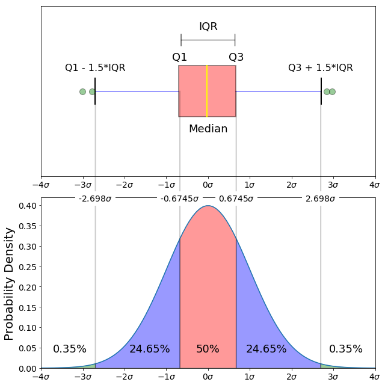

```python
np.random.seed(916170)

# connection path is here: https://stackoverflow.com/questions/6146290/plotting-a-line-over-several-graphs
mu, sigma = 0, 1 # mean and standard deviation
s = np.random.normal(mu, sigma, 1000)

fig, axes = plt.subplots(nrows = 2, ncols = 1, figsize=(9, 9))

# rectangular box plot
bplot = axes[0].boxplot(s,
                vert=False,
                patch_artist=True,
                showfliers=True, # This would show outliers (the remaining .7% of the data)
                positions = [0],
                boxprops = dict(linestyle='--', linewidth=2, color='Black', facecolor = 'red', alpha = .4),
                medianprops = dict(linestyle='-', linewidth=2, color='Yellow'),
                whiskerprops = dict(linestyle='-', linewidth=2, color='Blue', alpha = .4),
                capprops = dict(linestyle='-', linewidth=2, color='Black'),
                flierprops = dict(marker='o', markerfacecolor='green', markersize=10,
                  linestyle='none', alpha = .4),
                widths = .3,
                zorder = 1)

axes[0].set_xlim(-4, 4)
axes[0].set_yticks([])
x = np.linspace(-4, 4, num = 100)
constant = 1.0 / np.sqrt(2*np.pi)
pdf_normal_distribution = constant * np.exp((-x**2) / 2.0)

axes[0].annotate(r'',
            xy=(-.6745, .30), xycoords='data',
            xytext=(.6745, .30), textcoords='data',
            arrowprops=dict(arrowstyle="|-|",
                            connectionstyle="arc3")
            );

axes[0].text(0, .36, r"IQR",  horizontalalignment='center', fontsize=18)
axes[0].text(0, -.24, r"Median", horizontalalignment='center', fontsize=18);
axes[0].text(-.6745, .18, r"Q1", horizontalalignment='center', fontsize=18);
axes[0].text(-2.698, .12, r"Q1 - 1.5*IQR", horizontalalignment='center', fontsize=16);
axes[0].text(.6745, .18, r"Q3", horizontalalignment='center', fontsize=18);
axes[0].text(2.698, .12, r"Q3 + 1.5*IQR", horizontalalignment='center', fontsize=16);

axes[1].plot(x, pdf_normal_distribution, zorder= 2)
axes[1].set_xlim(-4, 4)
axes[1].set_ylim(0)
axes[1].set_ylabel('Probability Density', size = 20)

##############################
# lower box
con = ConnectionPatch(xyA=(-.6745, 0), xyB=(-.6745, 0),
    coordsA="data", coordsB="data", axesA=axes[1], axesB=axes[0],
    arrowstyle="-", linewidth=2, color="black", zorder = 2, alpha = .2)
axes[1].add_artist(con)

# upper box
con = ConnectionPatch(xyA=(.6745, 0), xyB=(.6745, 0),
    coordsA="data", coordsB="data", axesA=axes[1], axesB=axes[0],
    arrowstyle="-", linewidth=2, color="black", zorder = 2, alpha = .2)
axes[1].add_artist(con)

# lower whisker
con = ConnectionPatch(xyA=(-2.698, 0), xyB=(-2.698, 0),
    coordsA="data", coordsB="data", axesA=axes[1], axesB=axes[0],
    arrowstyle="-", linewidth=2, color="black", zorder = 2, alpha = .2)
axes[1].add_artist(con)

# upper whisker
con = ConnectionPatch(xyA=(2.698, 0), xyB=(2.698, 0),
    coordsA="data", coordsB="data", axesA=axes[1], axesB=axes[0],
    arrowstyle="-", linewidth=2, color="black", zorder = 2, alpha = .2)
axes[1].add_artist(con)

# Make the shaded center region to represent integral
a, b = -.6745, .6745
ix = np.linspace(a, b)
iy = normalProbabilityDensity(ix)
verts = [(-.6745, 0)] + list(zip(ix, iy)) + [(.6745, 0)]
poly = Polygon(verts, facecolor='red', edgecolor='0.2', alpha = .4)
axes[1].add_patch(poly)
axes[1].text(0, .04, r'{0:.0f}%'.format(result_n67_67*100),
         horizontalalignment='center', fontsize=18)

##############################
a, b = -2.698, -.6745# integral limits

# Make the shaded region
ix = np.linspace(a, b)
iy = normalProbabilityDensity(ix)
verts = [(a, 0)] + list(zip(ix, iy)) + [(b, 0)]
poly = Polygon(verts, facecolor='blue', edgecolor='0.2', alpha = .4)
axes[1].add_patch(poly);
axes[1].text(-1.40, .04, r'{0:.2f}%'.format(result_n2698_67*100),
         horizontalalignment='center', fontsize=18);

##############################
a, b = .6745, 2.698 # integral limits

# Make the shaded region
ix = np.linspace(a, b)
iy = normalProbabilityDensity(ix)
verts = [(a, 0)] + list(zip(ix, iy)) + [(b, 0)]
poly = Polygon(verts, facecolor='blue', edgecolor='0.2', alpha = .4)
axes[1].add_patch(poly);
axes[1].text(1.40, .04, r'{0:.2f}%'.format(result_67_2698*100),
         horizontalalignment='center', fontsize=18);

##############################
a, b = 2.698, 4 # integral limits

# Make the shaded region
ix = np.linspace(a, b)
iy = normalProbabilityDensity(ix)
verts = [(a, 0)] + list(zip(ix, iy)) + [(b, 0)]
poly = Polygon(verts, facecolor='green', edgecolor='0.2', alpha = .4)
axes[1].add_patch(poly);
axes[1].text(3.3, .04, r'{0:.2f}%'.format(result_2698_inf*100),
         horizontalalignment='center', fontsize=18);

##############################
a, b = -4, -2.698 # integral limits

# Make the shaded region
ix = np.linspace(a, b)
iy = normalProbabilityDensity(ix)
verts = [(a, 0)] + list(zip(ix, iy)) + [(b, 0)]
poly = Polygon(verts, facecolor='green', edgecolor='0.2', alpha = .4)
axes[1].add_patch(poly);
axes[1].text(-3.3, .04, r'{0:.2f}%'.format(result_ninf_n2698*100),
         horizontalalignment='center', fontsize=18);

##############################
xTickLabels = [r'$-4\sigma$',
               r'$-3\sigma$',
               r'$-2\sigma$',
               r'$-1\sigma$',
               r'$0\sigma$',
               r'$1\sigma$',
               r'$2\sigma$',
               r'$3\sigma$',
               r'$4\sigma$']

yTickLabels = ['0.00',
               '0.05',
               '0.10',
               '0.15',
               '0.20',
               '0.25',
               '0.30',
               '0.35',
               '0.40']

# Make both x axis into standard deviations
axes[0].set_xticklabels(xTickLabels, fontsize = 14)
axes[1].set_xticklabels(xTickLabels, fontsize = 14)

# Only the PDF needs y ticks
axes[1].set_yticklabels(yTickLabels, fontsize = 14)

##############################
# Add -2.698, -.6745, .6745, 2.698 text without background
axes[1].text(-.6745,.41, r'{0:.4f}'.format(-.6745) + '$\sigma$', horizontalalignment='center', fontsize=14,
            bbox={'facecolor':'white', 'edgecolor':'none', 'pad':5});

axes[1].text(.6745, .410, r'{0:.4f}'.format(.6745) + '$\sigma$', horizontalalignment='center', fontsize=14,
            bbox={'facecolor':'white', 'edgecolor':'none', 'pad':5});

axes[1].text(-2.698, .410, r'{0:.3f}'.format(-2.698) + '$\sigma$', horizontalalignment='center', fontsize=14,
            bbox={'facecolor':'white', 'edgecolor':'none', 'pad':5});

axes[1].text(2.698, .410, r'{0:.3f}'.format(2.698) + '$\sigma$', horizontalalignment='center', fontsize=14,
            bbox={'facecolor':'white', 'edgecolor':'none', 'pad':5});

fig.tight_layout()
fig.savefig('images/entireboxplotNormalDistribution.png', dpi = 900)
```

## Explaining Inner Fence, Outer Fence, IQR Math

Idea is to have all the math in one place just to show people.

## Negative Infinity to Positive Infinity

For any PDF, the area under the curve must be 1

**You will also find that it is also possible for observations to fall 4, 5 or even more standard deviations from the mean, but this is very rare if you have a normal or nearly normal distribution.**

## Boxplot Documentation Used

General boxplot documentation: https://matplotlib.org/api/_as_gen/matplotlib.pyplot.boxplot.html

Changing Color of Boxplot: https://matplotlib.org/examples/statistics/boxplot_color_demo.html

Properties of a box plot: https://matplotlib.org/examples/statistics/boxplot_demo.html

How I plotted over multiple subplots: https://stackoverflow.com/questions/6146290/plotting-a-line-over-several-graphs

Back No Border but have background for ax text: https://stackoverflow.com/questions/27531290/remove-matplotlib-text-plot-border